# Minha Postagem com HTML Gerado

## **LPSB3**

O mercado de ações começou a quarta-feira, 2025-08-27, com um tom mais calmo para o ativo LPSB3. A ação abriu em R$ 1,51 e fechou em R$ 1,53, mostrando uma variação zero percentual em relação ao dia anterior. No entanto, foi apenas no início da tarde que as coisas começaram a se mover.Às 12:30:00, houve um ponto de destaque nas negociações do LPSB3, quando a quantidade negociada representou 11,7% do total negociado no dia para o ativo. Nesse momento, a cotação da ação sofreu uma retração de -2,47%, mas logo após isso, a tendência se estabilizou e a ação fechou com um desempenho muito similar ao dia anterior.Em termos de performance, o LPSB3 registrou uma variação mensal de 10,9% e trimestral de -4,38%. No entanto, é interessante notar que a variação anual da ação é de 12,5%, demonstrando um crescimento geral. Além disso, a variação semanal do ativo é de 4,79%, mostrando uma tendência ascendente.Em resumo, o LPSB3 começou a quarta-feira com um tom mais calmo, mas apresentou um ponto de destaque no início da tarde que impactou na cotação da ação. Embora tenha havido uma retração momentânea, a ação fechou com um desempenho muito similar ao dia anterior, mostrando uma tendência geral ascendente. Veja a seguir o gráfico do intraday com o destaque do outlier: as setas amarelas destacam o momento e o volume negociado no ponto de outlier. A linha violeta demonstra a tendência do preço antes e depois do destaque.

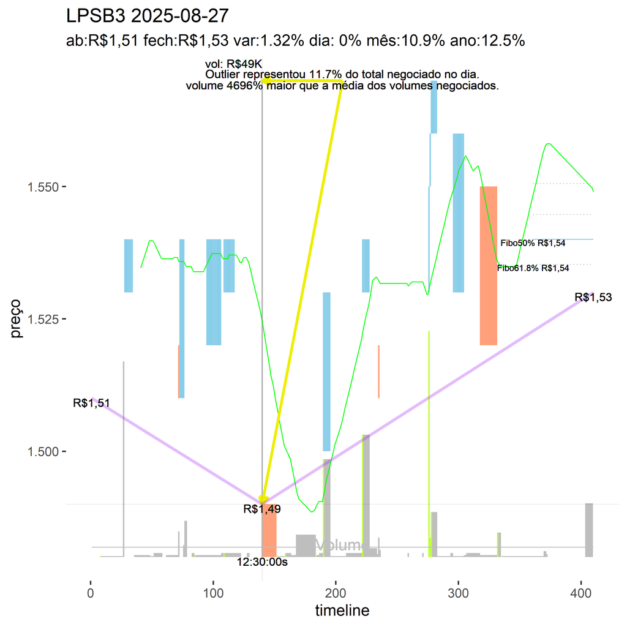

A seguir, desempenho do ativo ao longo do tempo:

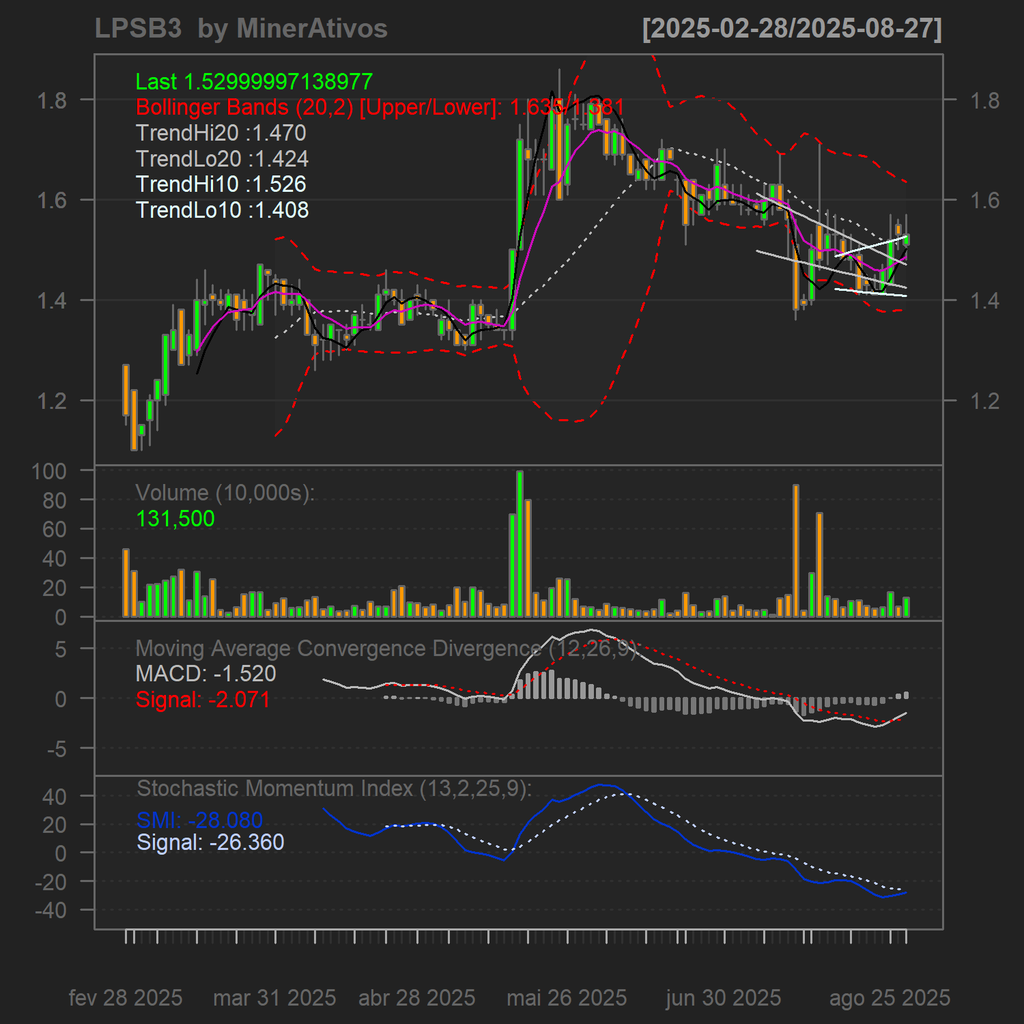

[figure not shown]